# Analysis of RNA-seq data in R and Bioconductor

Rockefeller University, Bioinformatics Resource Centre

http://rockefelleruniversity.github.io/RU_RNAseq/

## RNA-seq

RNA-seq offers a method to simulateously measure the genome wide expression of annotated and novel transcripts.

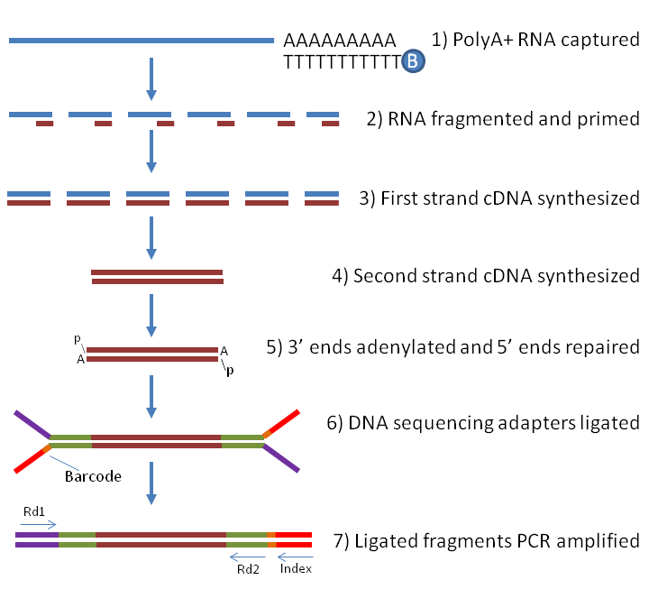

## RNA-seq for differential transcript usage

A less frequent but important goal in RNAseq is to identify any changes in the relative abundance of transcripts for a gene between conditions. This may be able to identify changes in a genes’ functional role between conditions. i.e. One isoform of a protein may bind and activate, another may simply bind and obstruct other active forms. We call this differential transcript usage (DTU).

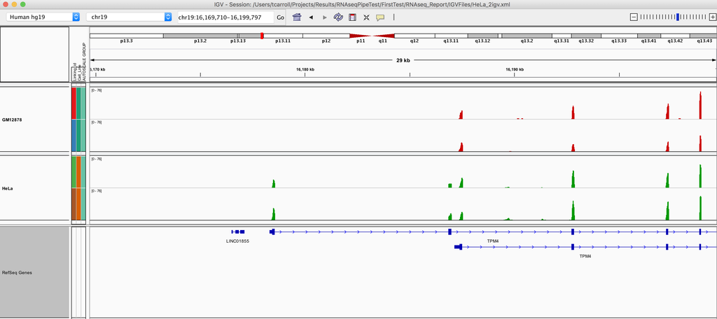

## What we will cover.

In the RNAseq sessions we will identify differential gene expression between our T-cell sample groups as well identify potential differential transcript usage. We will further identify biological functions associated with genes and visualise these in IGV and in summary plots.

In our first session we will look at two separate ways we can gain gene expression estimates from raw sequencing data as fastQ files.

# Working with raw RNAseq sequence data.

We can subsample from a fastQ file using functions in **ShortRead** package.

Here we use the [**FastqSampler** and **yield** function](https://rockefelleruniversity.github.io/Bioconductor_Introduction/r_course/presentations/slides/FastQInBioconductor.html#39) to randomly sample a defined number of reads from a fastQ file. Here we subsample 1 million reads.

```r
library(ShortRead)
fqSample <- FastqSampler("~/Downloads/ENCFF332KDA.fastq.gz",n=10^6)
fastq <- yield(fqSample)
fastq
```

```
## class: ShortReadQ
## length: 1000000 reads; width: 50 cycles
```

# Working with raw RNAseq sequence data.

We can plot the abundance of DNA bases (A,C,G,T) over the length of read to see any biases.

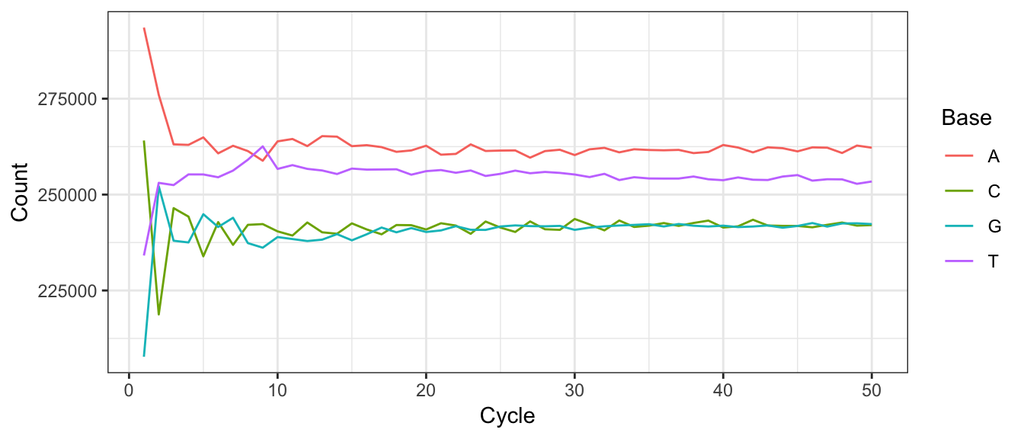

```r
library(ggplot2)
AFreq <- readSequences_AlpbyCycle["A",]
CFreq <- readSequences_AlpbyCycle["C",]
GFreq <- readSequences_AlpbyCycle["G",]
TFreq <- readSequences_AlpbyCycle["T",]
toPlot <- data.frame(Count=c(AFreq,CFreq,GFreq,TFreq),
                     Cycle=rep(1:50,4),
                     Base=rep(c("A","C","G","T"),each=50))
ggplot(toPlot,aes(y=Count,x=Cycle,colour=Base))+geom_line()+theme_bw()
```

# Working with raw RNAseq sequence data.

A final essential check of fastq quality is to plot the quality of sequencing over the length of the read (and so over time). Here we can use the **as(MYQUALITIES,“matrix”)** function to translate our ASCI encoded scores into numeric values and create a boxplot for visualisation.

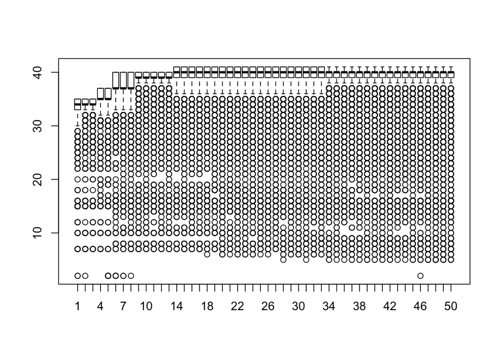

```r
qualAsMatrix <- as(readQuality,"matrix")
boxplot(qualAsMatrix[1:10000,])
```

# Creating a reference genome.

First we need to retrieve the sequence information for the genome of interest in [FASTA format](https://rockefelleruniversity.github.io/Genomic_Data/genomicFileFormats.html#/6)

We can use the [BSgenome libraries to retrieve the full sequence information.](https://rockefelleruniversity.github.io/Bioconductor_Introduction/r_course/presentations/slides/SequencesInBioconductor.html#4)

For the mouse mm10 genome we load the package **BSgenome.Mmusculus.UCSC.mm10**.

```r
library(BSgenome.Mmusculus.UCSC.mm10)
BSgenome.Mmusculus.UCSC.mm10
```

```
## Mouse genome:
## # organism: Mus musculus (Mouse)
## # provider: UCSC
## # provider version: mm10
## # release date: Dec. 2011
## # release name: Genome Reference Consortium GRCm38
## # 66 sequences:
## #   chr1                 chr2                 chr3
## #   chr4                 chr5                 chr6
## #   chr7                 chr8                 chr9
## #   chr10                chr11                chr12
## #   chr13                chr14                chr15
## #   ...                  ...                  ...
## #   chrUn_GL456372       chrUn_GL456378       chrUn_GL456379
## #   chrUn_GL456381       chrUn_GL456382       chrUn_GL456383
## #   chrUn_GL456385       chrUn_GL456387       chrUn_GL456389
## #   chrUn_GL456390       chrUn_GL456392       chrUn_GL456393
## #   chrUn_GL456394       chrUn_GL456396       chrUn_JH584304
## # (use 'seqnames()' to see all the sequence names, use the '$' or '[['
## # operator to access a given sequence)
```

# Creating a reference genome.

Now we have a **DNAStringSet** object we can use the [**writeXStringSet** to create our FASTA file of sequences to align to.](https://rockefelleruniversity.github.io/Bioconductor_Introduction/r_course/presentations/slides/SequencesInBioconductor.html#17)

```r
writeXStringSet(mainChrSeqSet,
                "BSgenome.Mmusculus.UCSC.mm10.mainChrs.fa")
```

# QuasR splice-aware with BSGenome object

We can now align our data by using the **qAlign()** function.

The **qAlign()** function requires the path to our sample table file and the path of a FASTA file to align sequence reads against.

A major difference now compared to aligning ChIP-seq and ATAC-seq is we now set the parameter **splicedAlignment** to TRUE to allow us to map to/over splice junctions.

```r
library(QuasR)
qAlign("sampleTable.txt","BSgenome.Mmusculus.UCSC.mm10.mainChrs.fa",
       splicedAlignment=TRUE)
```

# Aligning RNAseq reads with Rsubread.

The **Rsubread** package offers a faster aligner than the QuasR package although the **Rsubread** package is only available on Mac OS and Linux.

As for ChIP-seq and ATAC-seq alignment with the **Rsubread** package we must first build our genome index for Rsubread using the **buildindex()** function.

The [**buildindex()** function simply takes the parameters of our desired index name and the FASTA file to build index from.](https://rockefelleruniversity.github.io/Bioconductor_Introduction/r_course/presentations/slides/AlignmentInBioconductor.html#34)

```r
library(Rsubread)
buildindex("BSgenome.Mmusculus.UCSC.mm10.mainChrs",
           "BSgenome.Mmusculus.UCSC.mm10.mainChrs.fa")
```

# Sort and index reads.

As before, we sort and index our files using the [**Rsamtools** packages **sortBam()** and **indexBam()** functions respectively.](https://rockefelleruniversity.github.io/Bioconductor_Introduction/r_course/presentations/slides/AlignedDataInBioconductor.html#10)

The resulting sorted and indexed BAM file is now ready for use in external programs such as IGV as well as for further downstream analysis in R.

[figure not shown]

```r
library(Rsamtools)
sortBam("Treg_1.bam","Sorted_Treg_1.bam")
indexBam("Sorted_Treg_1.bam")
```

## Counting in gene models

Now we have our GRangesList with each entry corresponding to a gene and within each entry a GRanges object of the genes’ exons.

```r
geneExons[1:2]
```

```
## GRangesList object of length 2:
## $100009600
## GRanges object with 7 ranges and 2 metadata columns:
##       seqnames               ranges strand |   exon_id   exon_name
##          <Rle>            <IRanges>  <Rle> | <integer> <character>
##   [1]     chr9 [21062393, 21062717]      - |    134539        <NA>
##   [2]     chr9 [21062894, 21062987]      - |    134540        <NA>
##   [3]     chr9 [21063314, 21063396]      - |    134541        <NA>
##   [4]     chr9 [21066024, 21066377]      - |    134542        <NA>
##   [5]     chr9 [21066940, 21067925]      - |    134543        <NA>
##   [6]     chr9 [21068030, 21068117]      - |    134544        <NA>
##   [7]     chr9 [21073075, 21075496]      - |    134546        <NA>
##
## $100009609
## GRanges object with 6 ranges and 2 metadata columns:
##       seqnames               ranges strand | exon_id exon_name
##   [1]     chr7 [84940169, 84941088]      - |  109989      <NA>
##   [2]     chr7 [84943141, 84943264]      - |  109990      <NA>
##   [3]     chr7 [84943504, 84943722]      - |  109991      <NA>
##   [4]     chr7 [84946200, 84947000]      - |  109992      <NA>
##   [5]     chr7 [84947372, 84947651]      - |  109993      <NA>
##   [6]     chr7 [84963816, 84964009]      - |  109994      <NA>
##
## -------
## seqinfo: 66 sequences (1 circular) from mm10 genome
```

## Counting in exons models

If want to start to evaluate differential transcript usage we will often evaluate counts over exons and assess for changes in exon usage.

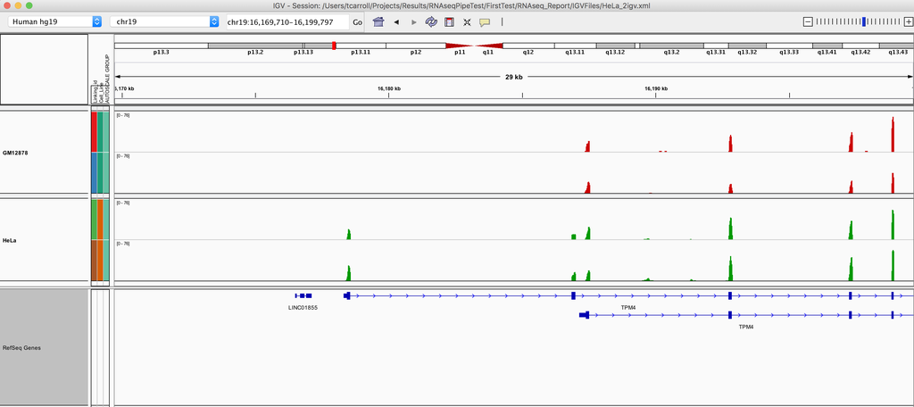

## Counting in exons models

We can then work to differentiate exons by collapsing exons to the nonoverlapping, disjoint regions.

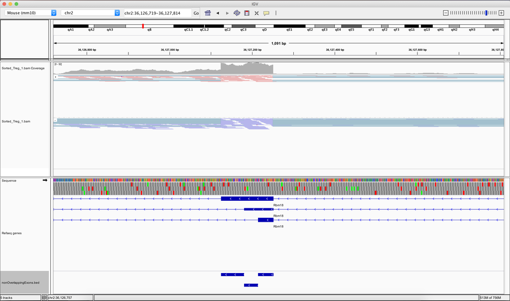

## Counting in exons models

We can now again use the **summarizeOverlaps()** function with our nonOverlapping, disjoint exons to identify a BAM file of interest.

We need to set the **inter.feature** to FALSE to allow us to count reads overlapping multiple features (such as a read spanning between two exons).

```r
tregExonCounts <- summarizeOverlaps(nonOverlappingExons,
                                    myBam,
                                    ignore.strand = TRUE,
                                    inter.feature=FALSE)
```

## Transcript quantification.

More recently methods have developed to directly quantify transcript abundance from fastq files using k-mer counting.

k-mer counting offers a super fast method of gaining transcript abundance estimates but do not produce a genomic alignment so not so useful for visualisation.

As we are most often interested in gene expression changes this offers a fast alternative to counting for alignment and counting.

The two leading softwares for k-mer counting

- [Salmon](http://salmon.readthedocs.io/en/latest/) - Relationship with DESeq2.
- [Kallisto](https://pachterlab.github.io/kallisto/about). - History of splice aware aligners and transcript quantification.

## Reference for transcript quantification.

First we need to produce a FASTA file of transcript sequences. We can use the GenomicFeatures’ packages **extractTranscriptSeqs** function to retrieve a DNAstringSet object of transcript sequences using our sequence data from **BSgenome.Mmusculus.UCSC.mm10** and gene models from **TxDb.Mmusculus.UCSC.mm10.knownGene** object.

```r
allTxSeq <- extractTranscriptSeqs(BSgenome.Mmusculus.UCSC.mm10,
                      TxDb.Mmusculus.UCSC.mm10.knownGene,
                      use.names=TRUE)
allTxSeq
```

```
##   A DNAStringSet instance of length 63759
##          width seq                                     names
##     [1]   2355 GCACTGTCCGCCAGCCGG...AAGGTGAGGTTGAAGGGT uc007afg.1
##     [2]   2433 GCACTGTCCGCCAGCCGG...AATTTAATTTTGGCTTTA uc007afh.1
##     [3]   2671 ACTTCTACTTTCCAGTCT...TTTTTGTTGTTAAACATA uc007afi.2
##     [4]   2668 ACTTCTACTTTCCAGTCT...TTTTTGTTGTTAAACATA uc011wht.1
##     [5]   2564 GCTGCTGCTGCTCCGCGG...TTTTTGTTGTTAAACATA uc011whu.1
##     ...    ... ...
## [63755]    168 TTCTTTCCTCTCTGGACA...ACGGAAACAGCCTCGACG uc029xhn.1
## [63756]   3321 TCTCTGCTGCCGGAGCAA...CAGTCATCTCTACCCACT uc029xhi.1
## [63757]   4188 GTGAAAATCCGAAAATGG...CTCCTTTGGTTCAACCCC uc057aqn.1
## [63758]    511 CTGTGGTCCTCTAACCTG...CATCTGACTGGCCTGCAG uc029xhj.1
## [63759]   1782 TCTCTGCTGCCGGAGCAA...TATATGAAAGTACTCAAA uc029xho.1
```

## Salmon index from R.

As with standard aligners, the first part of our quantification requires us to make an index from our FASTA file using the **Salmon index** command. We specify the transcript fasta file (-t) and index name (-i).

Here we arrange our Salmon command into a system call from R to allow us to loop through files.

```
~/bin/salmon index -i mm10Trans -t mm10Trans.fa
```

```r
salmonExec <- "~/bin/salmon index"
fastaTx <- "mm10Trans.fa"
indexName <- "mm10Trans"
salmonIndexCmd <- paste(salmonExec,
                        "-i",indexName,
                        "-t",fastaTx)
salmonIndexCmd
system(salmonIndexCmd,wait = TRUE)
```

```
## [1] "~/bin/salmon index -i mm10Trans -t mm10Trans.fa"
```

## Salmon outputs.

The output from Salmon is our quantification of transcripts in the **quant.sf** file in the user defined output directory.

We will use a new package **tximport** to handle these counts in next session but for now we can review file in standard R libraries.

```r
myQuant <- read.delim("~/Downloads/TReg_1_Quant/quant.sf")
myQuant[1:3,]
```

```
##         Name Length EffectiveLength      TPM NumReads
## 1 uc007afg.1   2355            2106  2.39769  166.473
## 2 uc007afh.1   2433            2184 60.28670 4340.770
## 3 uc007afi.2   2671            2422 35.67020 2848.220
```

# Time for an exercise.

Link_to_exercises

Link_to_answers